# STAA 577: Laboratory Eight Tree-based Methods (`tidyverse`)

## 4.2 Gini Importance

1. Mean decrease in accuracy of predictions on out-of-bag samples when variable is excluded.
2. Measure of the total decrease in node impurity that results from splits over the variable when averaged over all trees in forest.
3. See laboratory *followup_notes* file: `gini_backward_rf.nb.html` for additional discussion about `Gini` importance.

```r
importance(rf_boston6)    # built-in S3 print method for class `randomForest`
```

```
          %IncMSE IncNodePurity
crim    12.132320     986.50338
zn       1.955579      57.96945
indus    9.069302     882.78261
chas     2.210835      45.22941
nox     11.104823    1044.33776
rm      31.784033    6359.31971
age     10.962684     516.82969
dis     15.015236    1224.11605
rad      4.118011      95.94586
tax      8.587932     502.96719
ptratio 12.503896     830.77523
black    6.702609     341.30361
lstat   30.695224    7505.73936
```

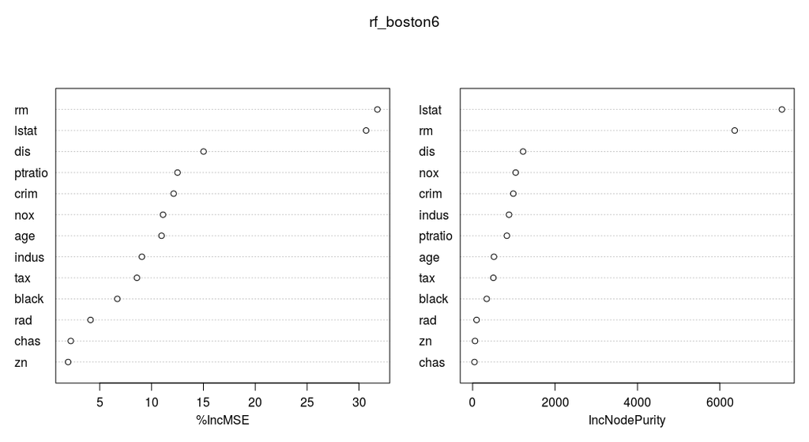

```r
varImpPlot(rf_boston6)    # built-in S3 plot method for class `randomForest`
```

## 4.3 Optimizing `mtry` and `ntree`

We can iterate over possible values of `mtry` and `ntree` to obtain a view of how these parameters affect `mse`. We will do with with the `purrr` package and plot with `ggplot2` all in one pipe chain.

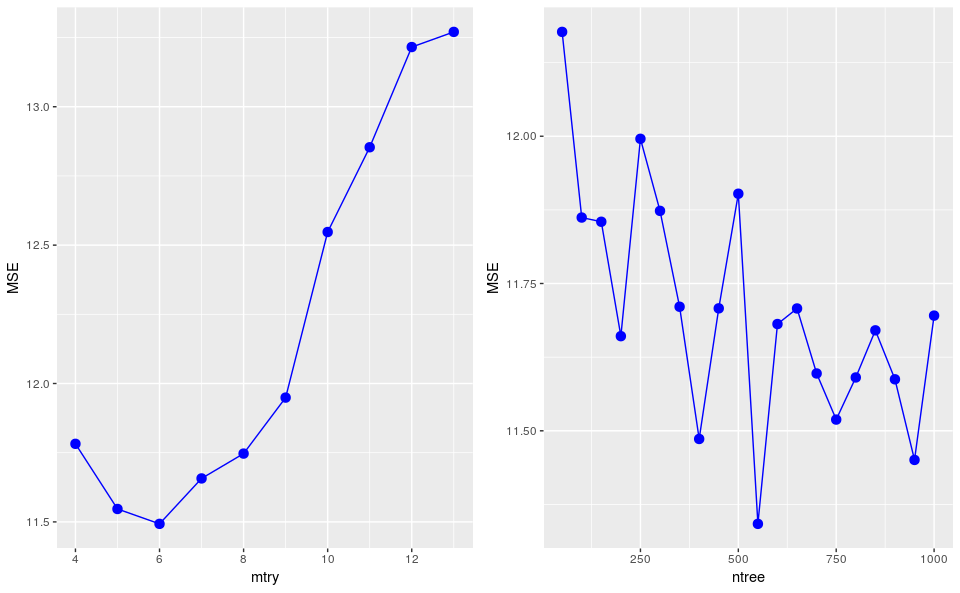

```r
set.seed(101)

# Establish values for mtry and ntree
n_feat    <- ncol(train_boston) - 1
mtry_vec  <- seq(floor(n_feat / 3), n_feat)
ntree_vec <- seq(50, 1000, by = 50)

mse_mtry <- purrr::map_dbl(mtry_vec, ~ {    # map_dbl -> output = double vector
  rf   <- randomForest::randomForest(medv ~ ., data = train_boston, mtry = .x)
  yhat <- predict(rf, newdata = dplyr::select(test_boston, -medv))
  mean((yhat - test_boston$medv)^2)
})

mse_ntree <- purrr::map_dbl(ntree_vec, ~ {
  rf   <- randomForest::randomForest(medv ~ ., data = train_boston, ntree = .x)
  yhat <- predict(rf, newdata = dplyr::select(test_boston, -medv))
  mean((yhat - test_boston$medv)^2)
})

gg <- list()
gg$mtry <- tibble::tibble(mtry = mtry_vec,
                          MSE  = mse_mtry) %>%
  ggplot(aes(x = mtry, y = MSE)) +
    geom_point(size = 3, colour = "blue") +
    geom_line(colour = "blue") +
    NULL
gg$ntree <- tibble::tibble(ntree = ntree_vec,
                           MSE   = mse_ntree) %>%
  ggplot(aes(x = ntree, y = MSE)) +
    geom_point(size = 3, colour = "blue") +
    geom_line(colour = "blue") +
    NULL

gridExtra::grid.arrange(gg$mtry, gg$ntree, ncol = 2)   # plot in 1x2 grid
```

# 5 Boosting

Boosting is performed via the `gbm::gbm()` function in `R`, which fits “Generalized Boosted Regression Models”. Recall that:

- Argument `distribution = "gaussian"` fits regression models
- Argument `distribution = "bernoulli"` fits classification models

|  | var | rel.inf |
| --- | --- | --- |
| lstat | lstat | 37.0661275 |
| rm | rm | 25.3533123 |
| dis | dis | 11.7903016 |
| crim | crim | 8.0388750 |
| black | black | 4.2531659 |
| nox | nox | 3.5058570 |
| age | age | 3.4868724 |
| ptratio | ptratio | 2.2500385 |
| indus | indus | 1.7725070 |
| tax | tax | 1.1836592 |

[output cut: 3 more lines]

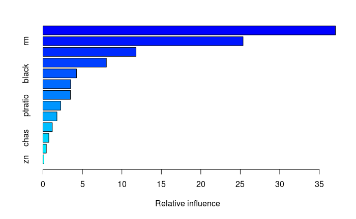

```r
set.seed(1)
gbm_boston1 <- gbm::gbm(medv ~ ., data = train_boston,
                        distribution = "gaussian",
                        n.trees = 5000, interaction.depth = 4)

# Relative influence
summary(gbm_boston1)
```

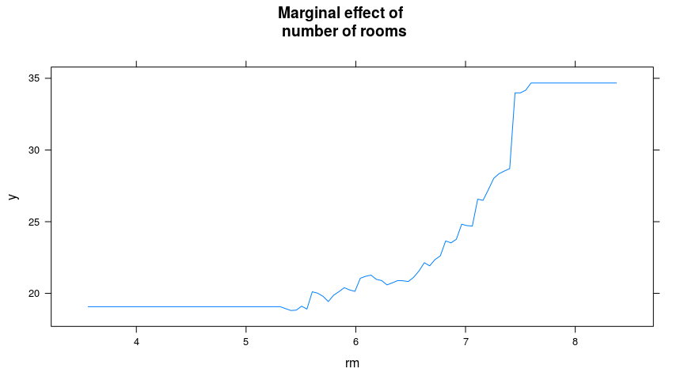

```r
# Partial dependence plots illustrate the marginal effect of the
# selected variables on the response after integrating out the other variables
# Using the built-in S3 plot method `plot.gbm()`
plot(gbm_boston1, i = "rm", main = "Marginal effect of \n number of rooms")
```

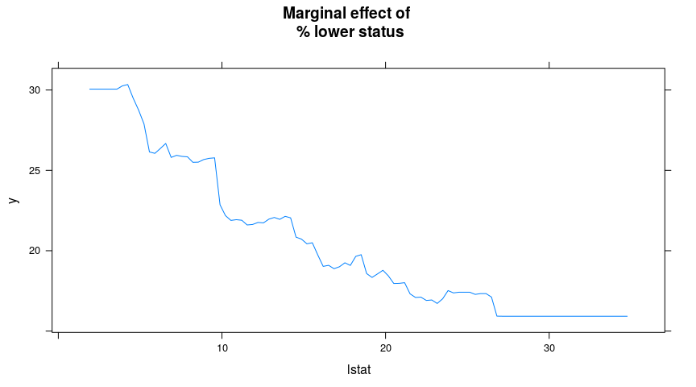

```r
plot(gbm_boston1, i = "lstat", main = "Marginal effect of \n % lower status")
```

## 5.1 Choice of shrinkage parameter

```r
# Shrinkage parameter = 0.001 (default)
yhat_gbm1 <- predict(gbm_boston1, newdata = dplyr::select(test_boston, -medv),
                     n.trees = 5000)
mse5 <- mean((yhat_gbm1 - test_boston$medv)^2)
mse5
```

```
[1] 10.81479
```

```r
# Shrinkage parameter = 0.2
gbm_boston0.2 <- gbm::gbm(medv ~ ., data = train_boston,
                          distribution = "gaussian", n.trees = 5000,
                          interaction.depth = 4, shrinkage = 0.2,
                          verbose = FALSE)
yhat_gbm0.2 <- predict(gbm_boston0.2,
                       newdata = dplyr::select(test_boston, -medv),
                       n.trees = 5000)
mse6 <- mean((yhat_gbm0.2 - test_boston$medv)^2)
mse6
```

```
[1] 11.51109
```

# 6 Appendix: CART via `caret`

The [caret](http://topepo.github.io/caret/index.html) package also provides a convenient framework for fitting cross-validated CART models in `R`.

Two notes:

- The `caret` package will “soon” be replaced by the now in development `parsnip` package
- Cross-validation is *built-in* to the ensemble `random forest` algorithm

```r
ctrl <- caret::trainControl(
  method = "cv",
  classProbs = TRUE,    # predict the probabilities
  # Compute the ROC AUC as well as the sens and
  # spec from the default 50% cutoff. The
  # function `twoClassSummary` produces those.
  summaryFunction = caret::twoClassSummary,
  savePredictions = "final",
  sampling = "down"  # for class imbalances; random down-sample prevelant class
)

set.seed(101)
cart_caret <- caret::train(
  x = dplyr::select(train_car, -High),  # no cheating!; rm 'truth' -> High
  y = train_car$High,                   # provide 'truth' as vector
  method = "rpart2",                # fit models via `rpart`
  metric = "ROC",                   # use ROC as cost function for performance
  tuneGrid = data.frame(maxdepth = 1:20),  # turning parameter; tree depth
  trControl = ctrl                  # use control object above as settings
)

cart_caret               # View the object with S3 print method
```

```
CART

200 samples
 10 predictors
  2 classes: 'No', 'Yes'

No pre-processing
Resampling: Cross-Validated (10 fold)
Summary of sample sizes: 180, 180, 180, 180, 180, 180, ...
Addtional sampling using down-sampling

Resampling results across tuning parameters:

  maxdepth  ROC        Sens       Spec
   1        0.5729167  0.4583333  0.6875
   2        0.6312500  0.5583333  0.7375
   3        0.7234375  0.7166667  0.7375
   4        0.7536458  0.7500000  0.7375
   5        0.7531250  0.6916667  0.7625
   6        0.7536458  0.6916667  0.7750
   7        0.7536458  0.6916667  0.7750
   8        0.7536458  0.6916667  0.7750
   9        0.7536458  0.6916667  0.7750
  10        0.7536458  0.6916667  0.7750
  11        0.7536458  0.6916667  0.7750
  12        0.7536458  0.6916667  0.7750
  13        0.7536458  0.6916667  0.7750
  14        0.7536458  0.6916667  0.7750
  15        0.7536458  0.6916667  0.7750
  16        0.7536458  0.6916667  0.7750
  17        0.7536458  0.6916667  0.7750
  18        0.7536458  0.6916667  0.7750
  19        0.7536458  0.6916667  0.7750
  20        0.7536458  0.6916667  0.7750

ROC was used to select the optimal model using the largest value.
The final value used for the model was maxdepth = 4.
```

```r
cart_caret$finalModel    # View the `best model`
```

```
n= 160

node), split, n, loss, yval, (yprob)
      * denotes terminal node

 1) root 160 80 No (0.50000000 0.50000000)
   2) ShelveLoc=Bad,Medium 118 45 No (0.61864407 0.38135593)
     4) Price>=95 97 29 No (0.70103093 0.29896907)
       8) Advertising< 13.5 84 18 No (0.78571429 0.21428571) *
       9) Advertising>=13.5 13  2 Yes (0.15384615 0.84615385) *
     5) Price< 95 21  5 Yes (0.23809524 0.76190476)
      10) ShelveLoc=Bad 7  2 No (0.71428571 0.28571429) *
      11) ShelveLoc=Medium 14  0 Yes (0.00000000 1.00000000) *
   3) ShelveLoc=Good 42  7 Yes (0.16666667 0.83333333)
     6) Price>=142.5 7  2 No (0.71428571 0.28571429) *
     7) Price< 142.5 35  2 Yes (0.05714286 0.94285714) *
```

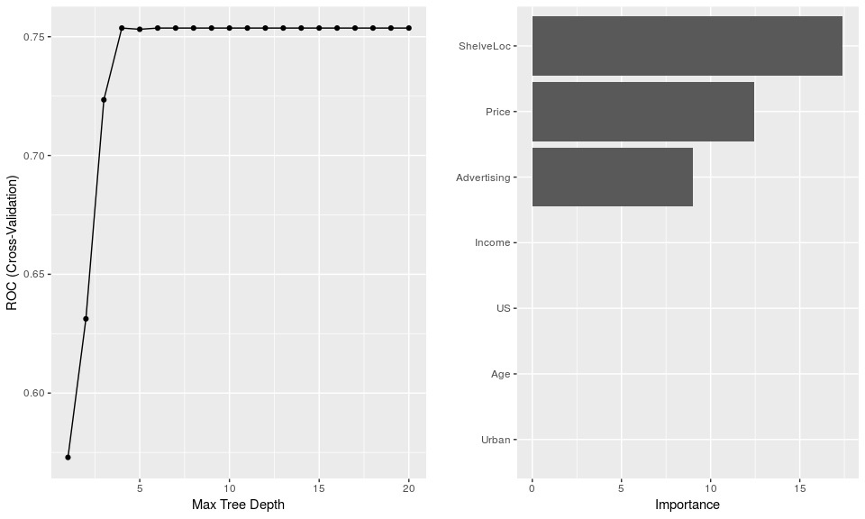

```r
caret_gg <- list()

# View CV ROCs by tuning par; S3 ggplot method
caret_gg$maxdepth <- ggplot(cart_caret)

# Variable importance
cart_imp <- varImp(cart_caret, scale = FALSE,
                   surrogates = FALSE, competes = FALSE)
caret_gg$imp <- ggplot(cart_imp, top = 7) + xlab("")
caret_gg %>%
  purrr::invoke(gridExtra::grid.arrange, ., ncol = 2)
```

# 7 Appendix: New CART plotting package `rpart.plot`

There is a relatively new package available on `CRAN` called `rpart.plot`, and it’s aim is to simplify the plotting of `rpart` class objects as well as improve their appearance. Admittedly, displaying all the information contained in a CART model is a daunting task to say the least! We leave it to you to decide if the authors have achieved their objective, but here are some examples from earlier in this Lab:

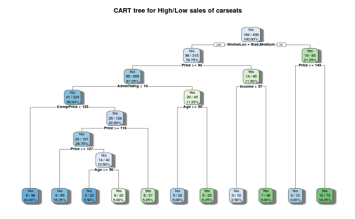

```r
# Copare to the initial tree in Section: Classification Trees
library(rpart.plot)
rpart::rpart(High ~ ., data = dplyr::select(Carseats, -Sales, -id),
             model = TRUE) %>%
  rpart.plot(digits = 4, shadow.col = "grey50", extra = 103,
             main = "CART tree for High/Low sales of carseats")
```

# 8 Resources

[CART Methods by Joao Neto](http://www.di.fc.ul.pt/~jpn/r/tree/tree.html)

Created on 2018-12-12 by [Rmarkdown](https://github.com/rstudio/rmarkdown) (v1.10) and R version 3.5.1 (2018-07-02).